# Global Moran’s I

## rows

### 2023 Moran’s I 0.116 `pseudo P-value 0.025`

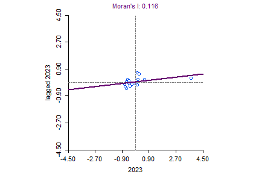

### 2022 Moran’s I 0.128 `pseudo P-value 0.026`

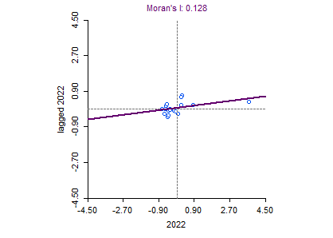

### 2021 Moran’s I 0.100 `pseudo P-value 0.033`

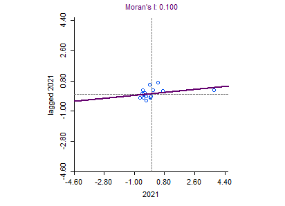

### 2020 Moran’s I 0.127 `pseudo P-value 0.014`

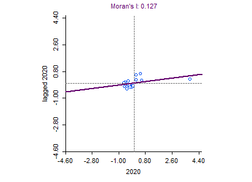

### 2019 Moran’s I 0.094 `pseudo P-value 0.034`

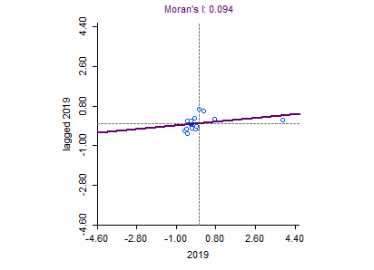

## rows

### 2018 Moran’s I 0.108 `pseudo P-value 0.025`

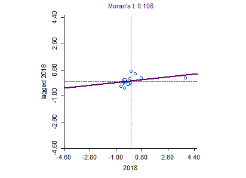

### 2017 Moran’s I 0.143 `pseudo P-value 0.016`

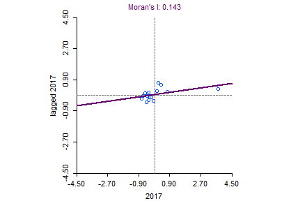

### 2016 Moran’s I 0.145 `pseudo P-value 0.021`

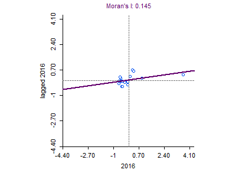

### 2015 Moran’s I 0.095 `pseudo P-value 0.044`

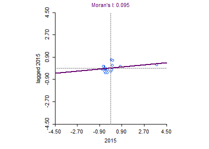

### 2014 Moran’s I 0.075 `pseudo P-value 0.038`

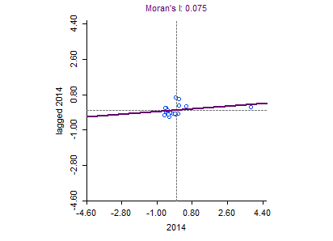

## rows

**The Moran scatter plot of TB incidences in Mueang Khon Kaen District, 2014–2023**

📖 All types of tuberculosis refer to TB cases diagnosed by a physician using at least one of the A15-A19 ICD-10 codes (the 10th revision of the International Classification of Diseases).

📝 Moran's indices were significantly positive (p-value < 0.05) in every year from 2014 to 2023, indicating spatial clustering across the study area during this period.

# Local Moran’s I

## rows

### 2023

### 2022

### 2021

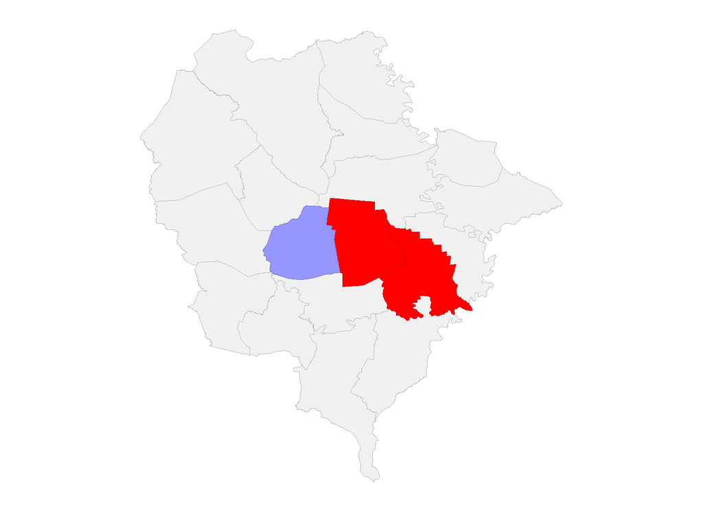

### 2020

### 2019

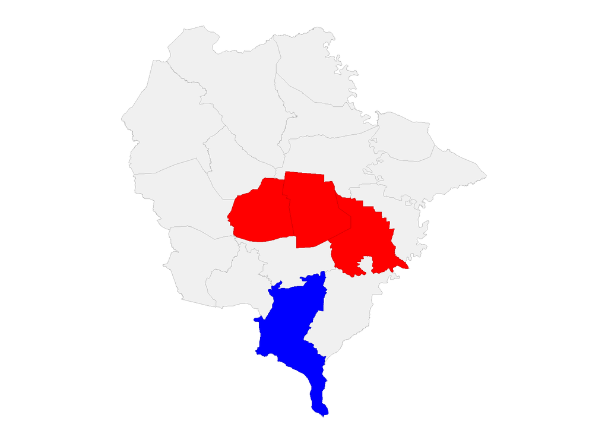

## rows

### 2018

### 2017

### 2016

### 2015

### 2014

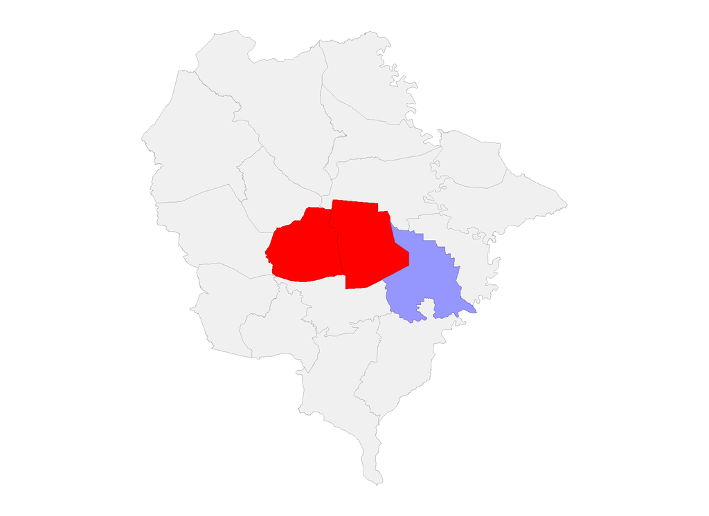

**LISA Cluster Map** Not Significant High-High Low-Low Low-High High-Low

📝 Results were mapped only when the p-value for a location was less than 0.05. Local Indicators of Spatial Association (LISA) were used to identify patterns of spatial clustering for each time period across the study areas. Hotspots of TB incidence from 2014 to 2023 were predominantly detected in the Nai Mueang, Phra Lab, and Ban Pet sub-districts, while cold spots were detected only in the Tha Phra sub-district in 2019. Low-high outliers were detected in Phra Lab in 2014 and Ban Pet in 2021

[interactive chart not shown]